# Algorithme de classification Knn

Nous appliquerons l’algorithme de la méthode des k plus proches voisins (Knn) dans le but de prédire le risque de crédit lors d'un demande de prêt bancaire.

## Chargement de librairies

```python
import numpy as np
import pandas as pd
from sklearn import metrics
import sklearn.datasets as ds
import sklearn.model_selection as ms
import sklearn.neighbors as nb
import matplotlib.pyplot as plt
from sklearn.preprocessing import MinMaxScaler
import seaborn as sns
```

## Importation des données

```python
dataframe = pd.read_csv(r"credit_german_nicer.csv",sep=';')
```

```python
dataframe.head(10)
```

|  | Cote_credit | Solde_compte | Duree_credit_mois | Historique_credit_statut | But_credit | Credit_demande | Epargne_statut | Duree_emploi | Taux_acompte | Statut_genre | ... | Duree_residence | Proprietes_biens | Age | Autres_credit | Type_logement | Credit_banque | Occupation | Personnes_charge | Tel | Etranger |
| --- | --- | --- | --- | --- | --- | --- | --- | --- | --- | --- | --- | --- | --- | --- | --- | --- | --- | --- | --- | --- | --- |
| 0 | 1 | 1 | 18 | 3 | 2 | 1049 | 1 | 1 | 4 | 1 | ... | 4 | 2 | 21 | 2 | 1 | 1 | 3 | 1 | 1 | 1 |
| 1 | 1 | 1 | 9 | 3 | 4 | 2799 | 1 | 2 | 2 | 2 | ... | 2 | 1 | 36 | 2 | 1 | 2 | 3 | 2 | 1 | 1 |
| 2 | 1 | 2 | 12 | 2 | 4 | 841 | 2 | 3 | 2 | 1 | ... | 4 | 1 | 23 | 2 | 1 | 1 | 2 | 1 | 1 | 1 |
| 3 | 1 | 1 | 12 | 3 | 4 | 2122 | 1 | 2 | 3 | 2 | ... | 2 | 1 | 39 | 2 | 1 | 2 | 2 | 2 | 1 | 2 |
| 4 | 1 | 1 | 12 | 3 | 4 | 2171 | 1 | 2 | 4 | 2 | ... | 4 | 2 | 38 | 1 | 2 | 2 | 2 | 1 | 1 | 2 |
| 5 | 1 | 1 | 10 | 3 | 4 | 2241 | 1 | 1 | 1 | 2 | ... | 3 | 1 | 48 | 2 | 1 | 2 | 2 | 2 | 1 | 2 |
| 6 | 1 | 1 | 8 | 3 | 4 | 3398 | 1 | 3 | 1 | 2 | ... | 4 | 1 | 39 | 2 | 2 | 2 | 2 | 1 | 1 | 2 |
| 7 | 1 | 1 | 6 | 3 | 4 | 1361 | 1 | 1 | 2 | 2 | ... | 4 | 1 | 40 | 2 | 2 | 1 | 2 | 2 | 1 | 2 |
| 8 | 1 | 3 | 18 | 3 | 3 | 1098 | 1 | 1 | 4 | 1 | ... | 4 | 3 | 65 | 2 | 2 | 2 | 1 | 1 | 1 | 1 |
| 9 | 1 | 2 | 24 | 2 | 3 | 3758 | 3 | 1 | 1 | 1 | ... | 4 | 4 | 23 | 2 | 1 | 1 | 1 | 1 | 1 | 1 |

10 rows × 21 columns

```python
print(dataframe.shape)
```

```
(1000, 21)
```

## Préparation des données pour le modèle

```python
X = dataframe[['Solde_compte','Duree_credit_mois','Historique_credit_statut','But_credit','Credit_demande','Epargne_statut','Duree_emploi','Taux_acompte','Statut_genre','Garant','Duree_residence',' Proprietes_biens','Age','Autres_credit','Type_logement','Credit_banque','Occupation','Personnes_charge','Tel','Etranger']].values
```

```python
y = dataframe['Cote_credit'].values
```

Nous allons créer les datasets pour l'apprentissage et pour le test du modèle. Dans ce cas, les datasets d'apprentissage X_train et X_test contiennent le 75% et le "25% respectivement des observations du dataframe X. De la même façon, les datasets y_train et y_test contiennent le 75% et le "25% respectivement des observations du dataframe y. Cette coupage est réalisé automatiquement grâce à la méthode 'train_test_split' de la librairie 'sklearn.model_selection'.

```python
X_train, X_test, y_train, y_test = ms.train_test_split (X, y, test_size = 0.25)
```

Nous pouvons constater dans les graphiques suivantes que les données des datasets X_train et X_test varient dans des échelles différentes.

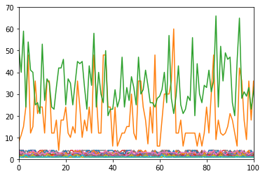

```python
plt.plot(X_train)
plt.axis([0, 100, 0, 70])
plt.show()
```

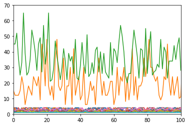

```python
plt.plot(X_test)
plt.axis([0, 100, 0, 70])
plt.show()
```

```python
scaler = MinMaxScaler()
X_train = scaler.fit_transform(X_train)
X_test = scaler.transform(X_test)
```

Maintenant, les datasets X_train et X_test ont la même échelle :

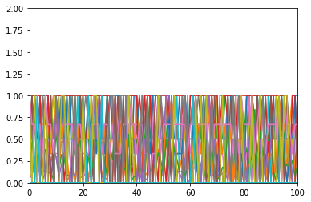

```python
plt.plot(X_train)
plt.axis([0, 100, 0, 2])
plt.show()
```

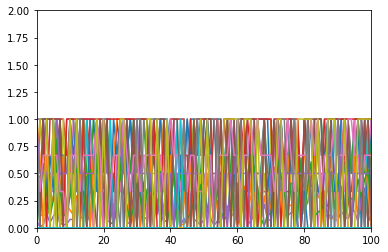

```python
plt.plot(X_test)
plt.axis([0, 100, 0, 2])
plt.show()
```

## Utilisation du modèle Knn

Dans cette étape, nous appliquons la méthode des k plus proches voisins(Knn) et nous utilisons les méthodes de la librairie sklearn.neighbors.

D'abord, nous définirons le nombre de voisins plus proches à 3 pour la classification et nous déterminons le modèle en utilisant X_train comme données d'apprentissage et y_train comme valeurs cibles.

```python
knn = nb.KNeighborsClassifier(n_neighbors = 3)
knn.fit(X_train, y_train)
```

```
KNeighborsClassifier(algorithm='auto', leaf_size=30, metric='minkowski',
           metric_params=None, n_jobs=1, n_neighbors=3, p=2,
           weights='uniform')
```

Ensuite, nous utilisons le modèle pour prédire la crédibilité des observations du dataset X_test :

```python
y_pred = knn.predict(X_test)
```

## Évaluation de performance

Pour valider la précision de la prédiction nous avons deux options : La première, en utilisant la fonction metrics.accuracy_score de la librerie sklearn/metrics :

```python
print ('La précision du classificateur K-NN sur le test set : ' + str(metrics.accuracy_score(y_test, y_pred)))
```

```
La précision du classificateur K-NN sur le test set : 0.668
```

La deuxième, en utilisant la fonction knn.score de la librairie du modèle Knn. Cette fonction va automatiquement appliquer les mêmes étapes précédentes de prédiction et validation avec metrics.

```python
print('La précision du classificateur K-NN sur le test set : '+ str(knn.score(X_test, y_test)))
```

```
La précision du classificateur K-NN sur le test set : 0.668
```

En conséquence, pour cette classification en utilisant un 3nn, nous avons un 67% de précision et un 33% d'erreur.

Pour confirmer ce résultat, nous utilisons la matrice de confusion de la librairie sklearn/metrics:

```
[[ 36  54]
 [ 29 131]]
```

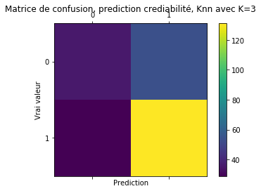

```python
labels = [0,1]
matrice_confusion=metrics.confusion_matrix(y_test, y_pred, labels)
print(matrice_confusion)

fig = plt.figure()
ax = fig.add_subplot(111)
cax = ax.matshow(matrice_confusion)
plt.title('Matrice de confusion, prediction crediabilité, Knn avec K=3')
fig.colorbar(cax)
ax.set_xticklabels([''] + labels)
ax.set_yticklabels([''] + labels)
plt.xlabel('Prediction')
plt.ylabel('Vrai valeur')
plt.show()
```

Cette fonction nous indique que des 250 observations du test nous avons : 131 VRAIS POSITIFS, 29 faux négatifs, 54 faux positifs, 36 VRAIS NÉGATIFS. Alors 167 des prédictions sont bonnes. Donc, nous confirmons le 67% de précision. De plus, dans le tableau suivant nous montre la précision, le rappel et le f1-score pour chaque valeur (0,1). Comme résultat nous avons : Précision : 71% des éléments ont été bien classés pour la valeur 1 et 55% pour la valeur 0. Rappel : 82% des éléments sont été bien classés par rapport au nombre d’éléments de la valeur 1 à prédire et 40% es élément sont été bien classés par rapport au nombre d’éléments de la valeur 0 à prédire f1-score : 76% est la moyenne harmonique entre la précision et le rappel de la valeur 1 et 46% est la moyenne harmonique entre la précision et le rappel de la valeur 0

```python
print(metrics.classification_report(y_test, y_pred))
```

```
             precision    recall  f1-score   support

          0       0.55      0.40      0.46        90
          1       0.71      0.82      0.76       160

avg / total       0.65      0.67      0.65       250
```

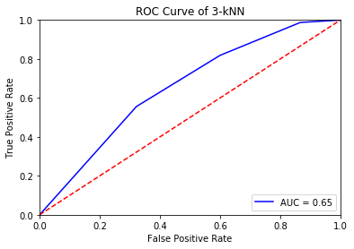

```python
from sklearn.metrics import roc_curve
from sklearn.metrics import auc

y_scores = knn.predict_proba(X_test)
fpr, tpr, threshold = roc_curve(y_test, y_scores[:,1])
roc_auc = auc(fpr, tpr)

plt.title('Receiver Operating Characteristic')
plt.plot(fpr, tpr, 'b', label = 'AUC = %0.2f' % roc_auc)
plt.legend(loc = 'lower right')
plt.plot([0, 1], [0, 1],'r--')
plt.xlim([0, 1])
plt.ylim([0, 1])
plt.ylabel('True Positive Rate')
plt.xlabel('False Positive Rate')
plt.title('ROC Curve of 3-kNN')
plt.show()
```

```python
k_range = range(1,50)
score = []
for k in k_range :
    knn = nb.KNeighborsClassifier(n_neighbors=k)
    knn.fit( X_train, y_train)
    y_pred = knn.predict(X_test)
    score.append(metrics.accuracy_score(y_test, y_pred))
```

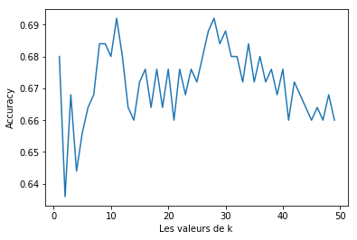

```python
plt.plot(k_range, score)
plt.xlabel("Les valeurs de k ")
plt.ylabel( "Accuracy")
plt.show()
```

## Une preuve de plus pour valider la performance de l'algorithme

Pemièrement, nous allons prendre seulement les variables qui ont une forte corrélation la cible. Ces variables ont été identifiées dans notre phase précédent d'exploration de données.

```python
X = dataframe[['Solde_compte','Duree_credit_mois','Historique_credit_statut','But_credit','Credit_demande','Epargne_statut','Duree_emploi','Taux_acompte',' Proprietes_biens','Credit_banque']].values
print(X.shape)
```

```
(1000, 10)
```

Deuxièmement, nous préparons de nouveau les data set d'apprentissage et de test et nous appliquons le modèle 3-knn.

```python
X_train, X_test, y_train, y_test = ms.train_test_split (X, y, test_size = 0.25)
scaler = MinMaxScaler()
X_train = scaler.fit_transform(X_train)
X_test = scaler.transform(X_test)
knn = nb.KNeighborsClassifier(n_neighbors = 3)
knn.fit(X_train, y_train)
print('La précision du classificateur K-NN sur le test set : '+ str(knn.score(X_test, y_test)))
```

```
La précision du classificateur K-NN sur le test set : 0.716
```

Donc, en choisissant les variables de meilleure corrélation, la précision de l'algorithme a augmenté 4.8%.

```python
knn = nb.KNeighborsClassifier(n_neighbors = 12)
knn.fit(X_train, y_train)
print('La précision du classificateur K-NN sur le test set : '+ str(knn.score(X_test, y_test)))
```

```
La précision du classificateur K-NN sur le test set : 0.724
```

En conclusion, nous pouvons toujours améliorer la performance de l'algorithme en choisissant les bonnes variables et le bon nombre de voisins K.